# ggplot2

## 4.14 Gráfico de burbujas

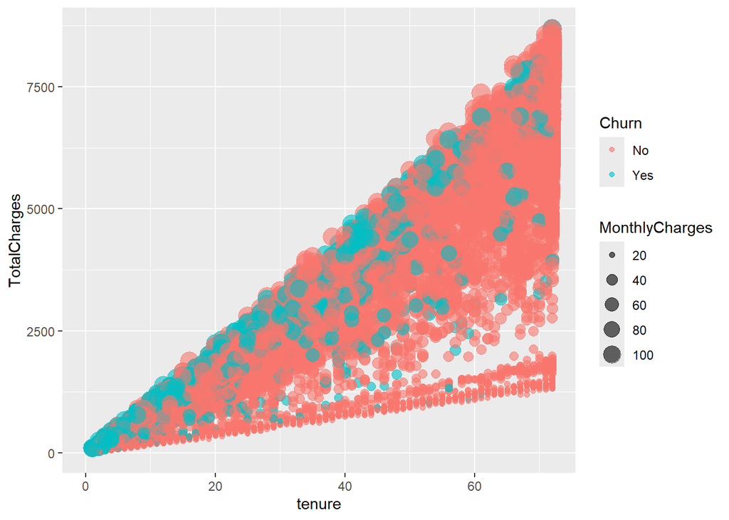

```r
ggplot(churn, aes(tenure, TotalCharges, size = MonthlyCharges, color = Churn)) +
  geom_point(alpha = 0.6)
```

**Interpretación**

En este gráfico cada punto representa un cliente. El tamaño de la burbuja indica el valor de los cargos mensuales, mientras que el color muestra si el cliente canceló el servicio. Esto permite analizar simultáneamente la relación entre permanencia, cargos totales y cancelación.

## 4.15 Gráfico estilo publicación

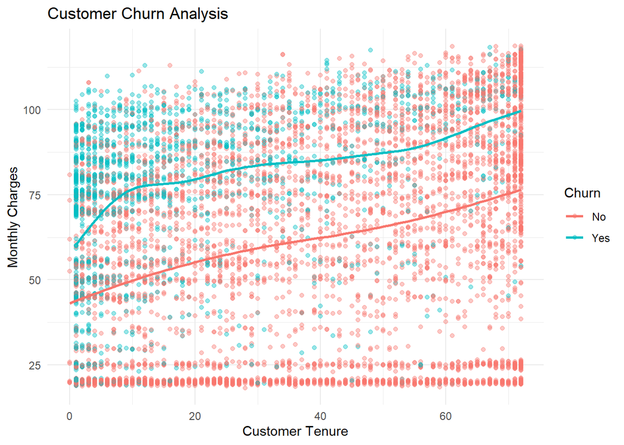

```r
ggplot(churn, aes(tenure, MonthlyCharges, color = Churn)) +
  geom_point(alpha = 0.4) +
  geom_smooth(se = FALSE) +
  theme_minimal() +
  labs(
    title = "Customer Churn Analysis",
    x = "Customer Tenure",
    y = "Monthly Charges"
  )
```

**Interpretación**

Este gráfico resume la relación entre la permanencia del cliente y los cargos mensuales, diferenciando por cancelación del servicio. La línea de tendencia ayuda a identificar patrones generales y facilita la interpretación visual de los datos.

# Conclusión

En este trabajo se aplicaron diferentes técnicas de visualización de datos utilizando ggplot2 en R para analizar distintos conjuntos de información. A través de gráficos como diagramas de dispersión, histogramas, boxplots y gráficos de barras, fue posible identificar patrones, observar la relación entre variables y comparar grupos de datos de forma clara.

Por ejemplo, en los gráficos de dispersión se observó la relación entre variables como la antigüedad del cliente y los cargos mensuales, mientras que los histogramas permitieron ver la distribución de los datos. Los boxplots ayudaron a comparar los cargos mensuales entre clientes que cancelaron y los que no, y los gráficos de barras mostraron la cantidad de clientes según el tipo de contrato.

El uso de elementos visuales como colores, tamaños y facetas permitió representar múltiples variables en un mismo gráfico, facilitando la interpretación de los resultados. En conclusión, ggplot2 es una herramienta muy útil para el análisis exploratorio de datos, ya que permite transformar la información en representaciones visuales claras que ayudan a comprender mejor los datos.